[figure not shown]

# Artificial Intelligence and Machine Learning

Project Python Foundations: FoodHub Data Analysis

[figure not shown]

### Context

The number of restaurants in New York is increasing day by day. Lots of students and busy professionals rely on those restaurants due to their hectic lifestyles. Online food delivery service is a great option for them. It provides them with good food from their favorite restaurants. A food aggregator company FoodHub offers access to multiple restaurants through a single smartphone app.

The app allows the restaurants to receive a direct online order from a customer. The app assigns a delivery person from the company to pick up the order after it is confirmed by the restaurant. The delivery person then uses the map to reach the restaurant and waits for the food package. Once the food package is handed over to the delivery person, he/she confirms the pick-up in the app and travels to the customer's location to deliver the food. The delivery person confirms the drop-off in the app after delivering the food package to the customer. The customer can rate the order in the app. The food aggregator earns money by collecting a fixed margin of the delivery order from the restaurants.

### Objective

The food aggregator company has stored the data of the different orders made by the registered customers in their online portal. They want to analyze the data to get a fair idea about the demand of different restaurants which will help them in enhancing their customer experience. Suppose you are hired as a Data Scientist in this company and the Data Science team has shared some of the key questions that need to be answered. Perform the data analysis to find answers to these questions that will help the company to improve the business.

### Data Description

The data contains the different data related to a food order. The detailed data dictionary is given below.

### Data Dictionary

- order_id: Unique ID of the order
- customer_id: ID of the customer who ordered the food
- restaurant_name: Name of the restaurant
- cuisine_type: Cuisine ordered by the customer
- cost_of_the_order: Cost of the order
- day_of_the_week: Indicates whether the order is placed on a weekday or weekend (The weekday is from Monday to Friday and the weekend is Saturday and Sunday)
- rating: Rating given by the customer out of 5
- food_preparation_time: Time (in minutes) taken by the restaurant to prepare the food. This is calculated by taking the difference between the timestamps of the restaurant's order confirmation and the delivery person's pick-up confirmation.
- delivery_time: Time (in minutes) taken by the delivery person to deliver the food package. This is calculated by taking the difference between the timestamps of the delivery person's pick-up confirmation and drop-off information

### Let us start by importing the required libraries

```python
# Installing the libraries with the specified version.
!pip install numpy==2.0.2 pandas==2.2.2 matplotlib==3.10.0 seaborn==0.13.2 -q --user
```

**Note**:

- After running the above cell, kindly restart the runtime (for Google Colab) or notebook kernel (for Jupyter Notebook), and run all cells sequentially from the next cell.
- On executing the above line of code, you might see a warning regarding package dependencies. This error message can be ignored as the above code ensures that all necessary libraries and their dependencies are maintained to successfully execute the code in **this notebook**.

```python
# Import libraries for data manipulation
import numpy as np
import pandas as pd

# Import libraries for data visualization
import matplotlib.pyplot as plt
import seaborn as sns

# Suppress warnings to keep the notebook clean
import warnings
warnings.filterwarnings('ignore')

# Ensure plots display inline inside the notebook
%matplotlib inline

# Set a consistent visual style for all plots
sns.set_style('whitegrid')
plt.rcParams['figure.figsize'] = (10, 5)
```

### Understanding the structure of the data

```python
# uncomment and run the below code snippets if the dataset is present in the Google Drive
from google.colab import drive
drive.mount('/content/drive')
```

```python
# Read the dataset into a pandas DataFrame
# '../dataset/' goes one folder up from the notebook, then into the dataset folder
df = pd.read_csv('/content/drive/MyDrive/pgp-aiml-uta-2026/pgp_aiml_workspace/projects/dataset/foodhub/foodhub_order.csv')

# Display a quick confirmation that the data loaded correctly
print('Dataset loaded successfully!')
print(f'Shape: {df.shape[0]} rows x {df.shape[1]} columns')
```

```
Dataset loaded successfully!
Shape: 1898 rows x 9 columns
```

```python
# View the first 5 rows to get a feel for the data
# This shows us column names, sample values, and helps spot any obvious issues
df.head()
```

|  | order_id | customer_id | restaurant_name | cuisine_type | cost_of_the_order | day_of_the_week | rating | food_preparation_time | delivery_time |
| --- | --- | --- | --- | --- | --- | --- | --- | --- | --- |
| 0 | 1477147 | 337525 | Hangawi | Korean | 30.75 | Weekend | Not given | 25 | 20 |
| 1 | 1477685 | 358141 | Blue Ribbon Sushi Izakaya | Japanese | 12.08 | Weekend | Not given | 25 | 23 |
| 2 | 1477070 | 66393 | Cafe Habana | Mexican | 12.23 | Weekday | 5 | 23 | 28 |
| 3 | 1477334 | 106968 | Blue Ribbon Fried Chicken | American | 29.20 | Weekend | 3 | 25 | 15 |
| 4 | 1478249 | 76942 | Dirty Bird to Go | American | 11.59 | Weekday | 4 | 25 | 24 |

### **Question 1:** How many rows and columns are present in the data? [0.5 mark]

```python
# df.shape returns a tuple: (number of rows, number of columns)
rows, cols = df.shape
print(f'Number of rows    : {rows}')
print(f'Number of columns : {cols}')
```

```
Number of rows    : 1898
Number of columns : 9
```

#### Observations:

- The dataset contains **1,898 rows** (orders) and **9 columns** (features).
- Each row represents one unique food order placed through the FoodHub app.
- With 9 features per order, we have enough information to analyze restaurants, cuisines, costs, ratings, and delivery times.

### **Question 2:** What are the datatypes of the different columns in the dataset? (The info() function can be used) [0.5 mark]

```python
# df.info() gives us column names, non-null counts, and data types in one shot
df.info()
```

```
<class 'pandas.core.frame.DataFrame'>
RangeIndex: 1898 entries, 0 to 1897
Data columns (total 9 columns):
 #   Column                 Non-Null Count  Dtype
---  ------                 --------------  -----
 0   order_id               1898 non-null   int64
 1   customer_id            1898 non-null   int64
 2   restaurant_name        1898 non-null   object
 3   cuisine_type           1898 non-null   object
 4   cost_of_the_order      1898 non-null   float64
 5   day_of_the_week        1898 non-null   object
 6   rating                 1898 non-null   object
 7   food_preparation_time  1898 non-null   int64
 8   delivery_time          1898 non-null   int64
dtypes: float64(1), int64(4), object(4)
memory usage: 133.6+ KB
```

#### Observations:

- **Integer (int64):** `order_id`, `customer_id`, `food_preparation_time`, `delivery_time` — all whole numbers, as expected.
- **Float (float64):** `cost_of_the_order` — decimal values since order costs include cents.
- **Object (string):** `restaurant_name`, `cuisine_type`, `day_of_the_week`, and `rating` — these are text columns.
- **Important note:** The `rating` column is stored as an *object* (string) rather than a number. This is because unrated orders contain the text `'Not given'` instead of a numeric value. We will need to handle this carefully in later questions.

### **Question 3:** Are there any missing values in the data? If yes, treat them using an appropriate method. [1 mark]

```python
# Step 1: Check for standard NaN (null) missing values
print('--- Standard null/NaN missing values ---')
print(df.isnull().sum())

# Step 2: The rating column uses 'Not given' as a placeholder for unrated orders
# This is NOT a standard NaN, so isnull() won't catch it — we check manually
print()
print('--- Hidden missing values: rating = "Not given" ---')
not_given_count = (df['rating'] == 'Not given').sum()
print(f"Orders with 'Not given' rating: {not_given_count}")

# Step 3: For analysis purposes, we replace 'Not given' with NaN
# This way pandas can properly exclude them from numeric calculations
df['rating'] = df['rating'].replace('Not given', np.nan)

print()
print('--- Missing values after treatment ---')
print(df.isnull().sum())
```

```
--- Standard null/NaN missing values ---
order_id                 0
customer_id              0
restaurant_name          0
cuisine_type             0
cost_of_the_order        0
day_of_the_week          0
rating                   0
food_preparation_time    0
delivery_time            0
dtype: int64

--- Hidden missing values: rating = "Not given" ---
Orders with 'Not given' rating: 736

--- Missing values after treatment ---
order_id                   0
customer_id                0
restaurant_name            0
cuisine_type               0
cost_of_the_order          0
day_of_the_week            0
rating                   736
food_preparation_time      0
delivery_time              0
dtype: int64
```

#### Observations:

- There are **no standard NaN/null values** in any column — the dataset is clean on the surface.
- However, the `rating` column contains **736 entries with the value `'Not given'`**, meaning those customers did not rate their order. This is a *hidden* missing value.
- We replaced `'Not given'` with `NaN` so that pandas can correctly exclude these from any numeric calculations on the rating column.
- 736 out of 1,898 orders (~38.8%) have no rating, which is a significant portion we must keep in mind during analysis.

### **Question 4:** Check the statistical summary of the data. What is the minimum, average, and maximum time it takes for food to be prepared once an order is placed? [2 marks]

```python
# df.describe() gives count, mean, std, min, 25%, 50%, 75%, and max for all numeric columns
df.describe().round(2)
```

|  | order_id | customer_id | cost_of_the_order | food_preparation_time | delivery_time |
| --- | --- | --- | --- | --- | --- |
| count | 1898.00 | 1898.00 | 1898.00 | 1898.00 | 1898.00 |
| mean | 1477495.50 | 171168.48 | 16.50 | 27.37 | 24.16 |
| std | 548.05 | 113698.14 | 7.48 | 4.63 | 4.97 |
| min | 1476547.00 | 1311.00 | 4.47 | 20.00 | 15.00 |
| 25% | 1477021.25 | 77787.75 | 12.08 | 23.00 | 20.00 |
| 50% | 1477495.50 | 128600.00 | 14.14 | 27.00 | 25.00 |
| 75% | 1477969.75 | 270525.00 | 22.30 | 31.00 | 28.00 |
| max | 1478444.00 | 405334.00 | 35.41 | 35.00 | 33.00 |

#### Observations:

- **Food preparation time:**
  - Minimum: **20 minutes**
  - Average: **27.37 minutes**
  - Maximum: **35 minutes**
- The range of 20–35 minutes is quite narrow, suggesting preparation times are consistent across restaurants.
- **Delivery time** ranges from 15 to 33 minutes, with an average of ~24.16 minutes.
- **Order cost** ranges from \$4.47 to \$35.41, with a mean of ~\$16.50. The median (\$14.14) is lower than the mean, suggesting a right-skewed distribution with some higher-cost orders pulling the average up.
- `order_id` and `customer_id` statistics are not meaningful for analysis as they are just identifier numbers.

### **Question 5:** How many orders are not rated? [1 mark]

```python
# Count orders where rating is NaN (we replaced 'Not given' with NaN in Q3)
unrated = df['rating'].isnull().sum()
total = len(df)
percentage = round((unrated / total) * 100, 2)

print(f'Number of unrated orders : {unrated}')
print(f'Total orders             : {total}')
print(f'Percentage not rated     : {percentage}%')
```

```
Number of unrated orders : 736
Total orders             : 1898
Percentage not rated     : 38.78%
```

#### Observations:

- **736 out of 1,898 orders (38.78%) were not rated** by customers.
- This is a large proportion — more than 1 in 3 customers did not leave a rating.
- This could indicate that the rating process is not prominent enough in the app, or customers are satisfied/indifferent and don't feel compelled to rate.
- For any analysis involving ratings, we must work only with the **1,162 rated orders** to avoid bias.

### Exploratory Data Analysis (EDA)

### **Question 6:** Explore all the variables and provide observations on their distributions. (Generally, histograms, boxplots, countplots, etc. are used for univariate exploration.) [9 marks]

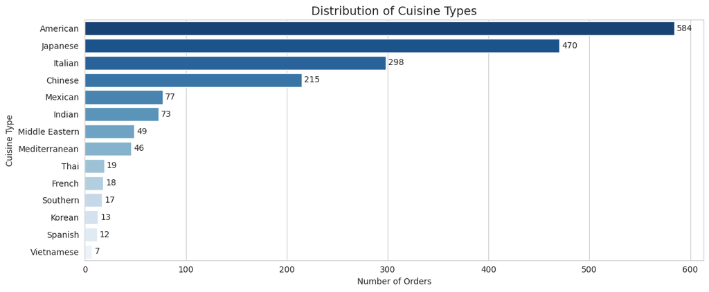

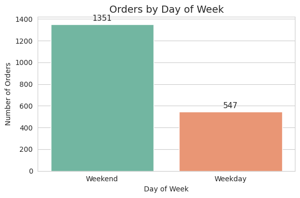

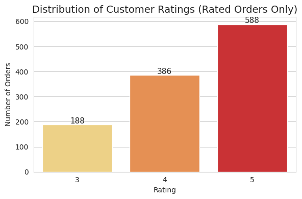

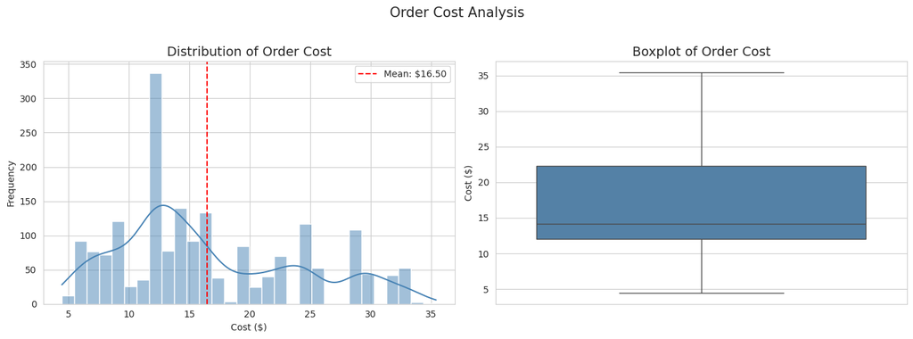

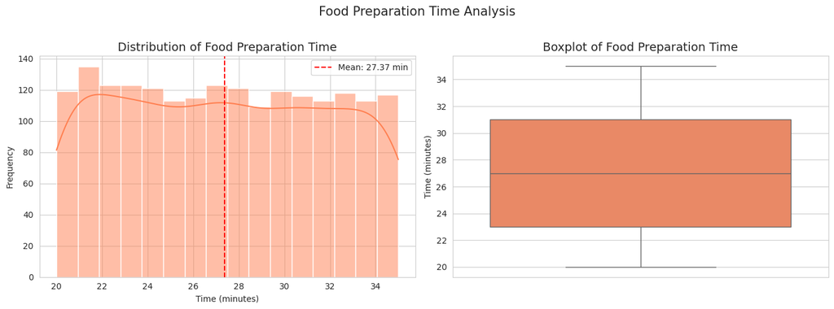

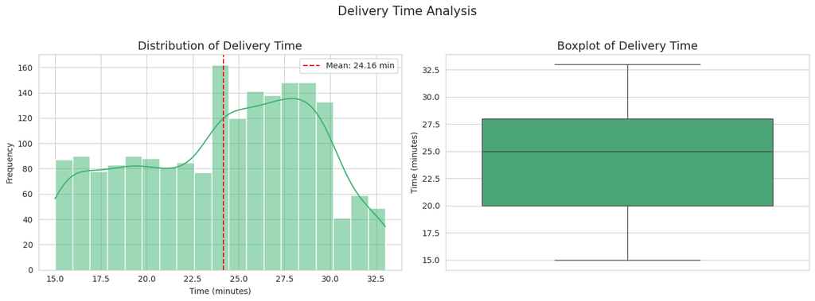

```
--- Summary Statistics for Numerical Variables ---
```

|  | cost_of_the_order | food_preparation_time | delivery_time |
| --- | --- | --- | --- |
| count | 1898.00 | 1898.00 | 1898.00 |
| mean | 16.50 | 27.37 | 24.16 |
| std | 7.48 | 4.63 | 4.97 |
| min | 4.47 | 20.00 | 15.00 |
| 25% | 12.08 | 23.00 | 20.00 |
| 50% | 14.14 | 27.00 | 25.00 |
| 75% | 22.30 | 31.00 | 28.00 |
| max | 35.41 | 35.00 | 33.00 |

```python
# ─────────────────────────────────────────────────────────────────
# Q6: Univariate Analysis — explore distributions of ALL variables
# ─────────────────────────────────────────────────────────────────

# --- 1. cuisine_type (categorical) ---
plt.figure(figsize=(12, 5))
cuisine_order = df['cuisine_type'].value_counts().index
sns.countplot(data=df, y='cuisine_type', order=cuisine_order, palette='Blues_r')
plt.title('Distribution of Cuisine Types', fontsize=14)
plt.xlabel('Number of Orders')
plt.ylabel('Cuisine Type')
for p in plt.gca().patches:
    plt.gca().annotate(f'{int(p.get_width())}',
                       xy=(p.get_width(), p.get_y() + p.get_height()/2),
                       xytext=(3, 0), textcoords='offset points', va='center', fontsize=10)
plt.tight_layout()
plt.show()

# --- 2. day_of_the_week (categorical) ---
plt.figure(figsize=(6, 4))
sns.countplot(data=df, x='day_of_the_week', palette='Set2',
              order=df['day_of_the_week'].value_counts().index)
plt.title('Orders by Day of Week', fontsize=14)
plt.xlabel('Day of Week')
plt.ylabel('Number of Orders')
for p in plt.gca().patches:
    plt.gca().annotate(f'{int(p.get_height())}',
                       xy=(p.get_x() + p.get_width()/2, p.get_height()),
                       xytext=(0, 5), textcoords='offset points', ha='center', fontsize=11)
plt.tight_layout()
plt.show()

# --- 3. rating (categorical — NaN excluded) ---
plt.figure(figsize=(6, 4))
rating_counts = df['rating'].dropna().astype(float).astype(int).value_counts().sort_index()
sns.barplot(x=rating_counts.index, y=rating_counts.values, palette='YlOrRd')
plt.title('Distribution of Customer Ratings (Rated Orders Only)', fontsize=14)
plt.xlabel('Rating')
plt.ylabel('Number of Orders')
for i, v in enumerate(rating_counts.values):
    plt.text(i, v + 5, str(v), ha='center', fontsize=11)
plt.tight_layout()
plt.show()

# --- 4. cost_of_the_order (numerical) — histogram + boxplot ---
fig, axes = plt.subplots(1, 2, figsize=(14, 5))
sns.histplot(df['cost_of_the_order'], bins=30, kde=True, color='steelblue', ax=axes[0])
axes[0].set_title('Distribution of Order Cost', fontsize=14)
axes[0].set_xlabel('Cost ($)')
axes[0].set_ylabel('Frequency')
axes[0].axvline(df['cost_of_the_order'].mean(), color='red', linestyle='--', label=f"Mean: ${df['cost_of_the_order'].mean():.2f}")
axes[0].legend()
sns.boxplot(y=df['cost_of_the_order'], color='steelblue', ax=axes[1])
axes[1].set_title('Boxplot of Order Cost', fontsize=14)
axes[1].set_ylabel('Cost ($)')
plt.suptitle('Order Cost Analysis', fontsize=15, y=1.02)
plt.tight_layout()
plt.show()

# --- 5. food_preparation_time (numerical) — histogram + boxplot ---
fig, axes = plt.subplots(1, 2, figsize=(14, 5))
sns.histplot(df['food_preparation_time'], bins=16, kde=True, color='coral', ax=axes[0])
axes[0].set_title('Distribution of Food Preparation Time', fontsize=14)
axes[0].set_xlabel('Time (minutes)')
axes[0].set_ylabel('Frequency')
axes[0].axvline(df['food_preparation_time'].mean(), color='red', linestyle='--',
                label=f"Mean: {df['food_preparation_time'].mean():.2f} min")
axes[0].legend()
sns.boxplot(y=df['food_preparation_time'], color='coral', ax=axes[1])
axes[1].set_title('Boxplot of Food Preparation Time', fontsize=14)
axes[1].set_ylabel('Time (minutes)')
plt.suptitle('Food Preparation Time Analysis', fontsize=15, y=1.02)
plt.tight_layout()
plt.show()

# --- 6. delivery_time (numerical) — histogram + boxplot ---
fig, axes = plt.subplots(1, 2, figsize=(14, 5))
sns.histplot(df['delivery_time'], bins=19, kde=True, color='mediumseagreen', ax=axes[0])
axes[0].set_title('Distribution of Delivery Time', fontsize=14)
axes[0].set_xlabel('Time (minutes)')
axes[0].set_ylabel('Frequency')
axes[0].axvline(df['delivery_time'].mean(), color='red', linestyle='--',
                label=f"Mean: {df['delivery_time'].mean():.2f} min")
axes[0].legend()
sns.boxplot(y=df['delivery_time'], color='mediumseagreen', ax=axes[1])
axes[1].set_title('Boxplot of Delivery Time', fontsize=14)
axes[1].set_ylabel('Time (minutes)')
plt.suptitle('Delivery Time Analysis', fontsize=15, y=1.02)
plt.tight_layout()
plt.show()

print('\n--- Summary Statistics for Numerical Variables ---')
df[['cost_of_the_order','food_preparation_time','delivery_time']].describe().round(2)
```

### **Question 7**: Which are the top 5 restaurants in terms of the number of orders received? [1 mark]

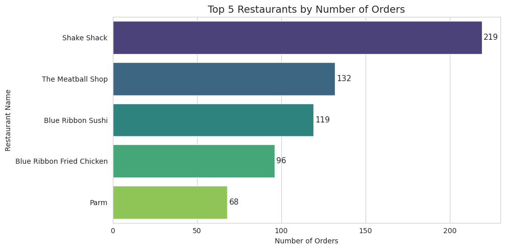

```
Top 5 Restaurants:
                           order_count
restaurant_name
Shake Shack                        219
The Meatball Shop                  132
Blue Ribbon Sushi                  119
Blue Ribbon Fried Chicken           96
Parm                                68
```

```python
# Count orders per restaurant, get top 5, and plot
top5_restaurants = df['restaurant_name'].value_counts().head(5)

plt.figure(figsize=(10, 5))
sns.barplot(x=top5_restaurants.values, y=top5_restaurants.index, palette='viridis')
plt.title('Top 5 Restaurants by Number of Orders', fontsize=14)
plt.xlabel('Number of Orders')
plt.ylabel('Restaurant Name')
for i, v in enumerate(top5_restaurants.values):
    plt.text(v + 1, i, str(v), va='center', fontsize=11)
plt.tight_layout()
plt.show()

print('\nTop 5 Restaurants:')
print(top5_restaurants.to_frame('order_count'))
```

### **Question 8**: Which is the most popular cuisine on weekends? [1 mark]

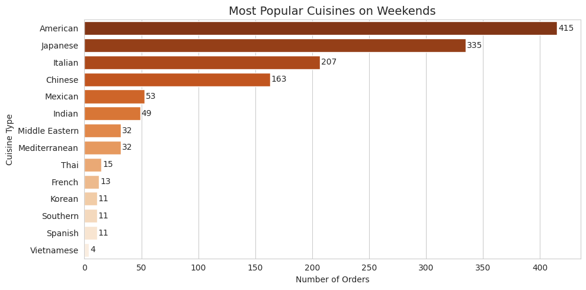

```
Most popular cuisine on weekends: American (415 orders)
```

```python
# Filter for weekend orders only, then count by cuisine
weekend_df = df[df['day_of_the_week'] == 'Weekend']
weekend_cuisine = weekend_df['cuisine_type'].value_counts()

plt.figure(figsize=(10, 5))
sns.barplot(x=weekend_cuisine.values, y=weekend_cuisine.index, palette='Oranges_r')
plt.title('Most Popular Cuisines on Weekends', fontsize=14)
plt.xlabel('Number of Orders')
plt.ylabel('Cuisine Type')
for i, v in enumerate(weekend_cuisine.values):
    plt.text(v + 1, i, str(v), va='center', fontsize=10)
plt.tight_layout()
plt.show()

most_popular = weekend_cuisine.idxmax()
print(f'Most popular cuisine on weekends: {most_popular} ({weekend_cuisine.max()} orders)')
```

#### Observations:

- **American cuisine is the most popular on weekends** with 415 orders, nearly 31% of all 1,351 weekend orders.
- Japanese cuisine comes in second (335 orders), followed by Italian (207) and Chinese (163).
- The high demand for American and Japanese cuisines on weekends suggests FoodHub should ensure strong restaurant partnerships in these categories for weekend coverage.
- Notably, weekends account for 71% of all orders (1,351 out of 1,898), making weekend performance critical to the business.

### **Question 9**: What percentage of the orders cost more than 20 dollars? [2 marks]

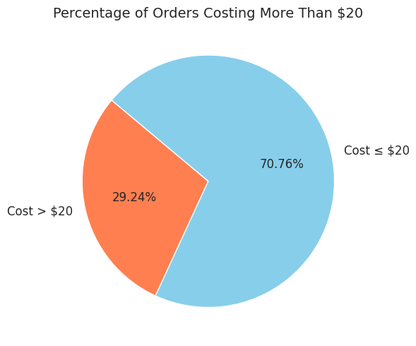

```
Orders costing more than $20 : 555
Total orders                 : 1898
Percentage                   : 29.24%
```

```python
# Count how many orders cost more than $20
orders_above_20 = (df['cost_of_the_order'] > 20).sum()
total_orders = len(df)
percentage_above_20 = round((orders_above_20 / total_orders) * 100, 2)

# Visualize the split with a pie chart
labels = ['Cost > $20', 'Cost ≤ $20']
sizes = [orders_above_20, total_orders - orders_above_20]
colors = ['#ff7f50', '#87ceeb']

plt.figure(figsize=(7, 5))
plt.pie(sizes, labels=labels, colors=colors, autopct='%1.2f%%',
        startangle=140, textprops={'fontsize': 12})
plt.title('Percentage of Orders Costing More Than $20', fontsize=14)
plt.tight_layout()
plt.show()

print(f'Orders costing more than $20 : {orders_above_20}')
print(f'Total orders                 : {total_orders}')
print(f'Percentage                   : {percentage_above_20}%')
```

#### Observations:

- **29.24% of orders (555 out of 1,898) cost more than \$20.**
- This means roughly 1 in 3 orders is a higher-value order — important for FoodHub's revenue since these orders also attract a higher 25% commission.
- The remaining 70.76% of orders are at \$20 or below, forming the bulk of order volume.
- From a business perspective, encouraging customers to spend above \$20 (e.g., through combo offers or promotions) could meaningfully boost revenue.

### **Question 10**: What is the mean order delivery time? [1 mark]

```
Mean delivery time: 24.16 minutes
```

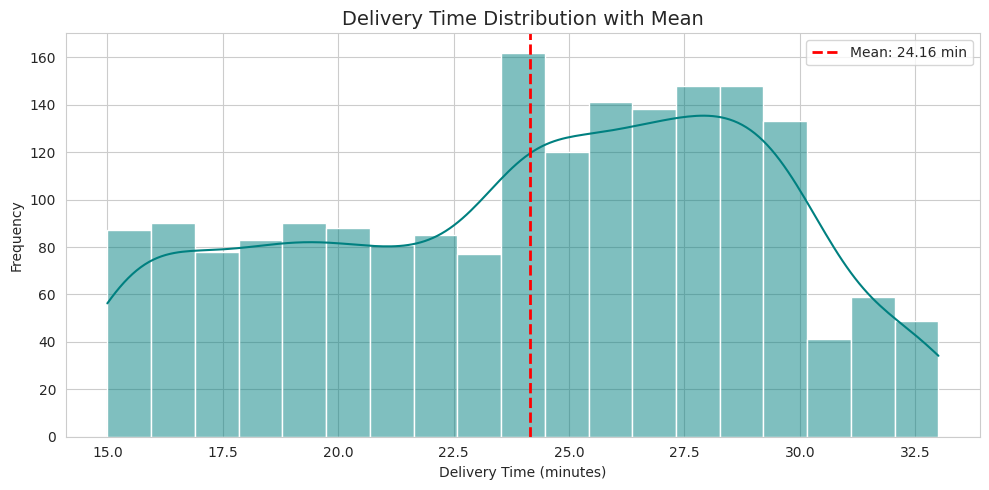

```python
# Calculate the mean delivery time across all orders
mean_delivery = round(df['delivery_time'].mean(), 2)
print(f'Mean delivery time: {mean_delivery} minutes')

# Visualize the distribution with a reference line at the mean
plt.figure(figsize=(10, 5))
sns.histplot(df['delivery_time'], bins=19, kde=True, color='teal')
plt.axvline(mean_delivery, color='red', linestyle='--', linewidth=2, label=f'Mean: {mean_delivery} min')
plt.title('Delivery Time Distribution with Mean', fontsize=14)
plt.xlabel('Delivery Time (minutes)')
plt.ylabel('Frequency')
plt.legend()
plt.tight_layout()
plt.show()
```

### **Question 11:** The company has decided to give 20% discount vouchers to the top 3 most frequent customers. Find the IDs of these customers and the number of orders they placed. [1 mark]

```
Top 3 Most Frequent Customers (eligible for 20% discount voucher):
 customer_id  order_count
       52832           13
       47440           10
       83287            9
```

[figure not shown]

```python
# Count how many orders each customer placed, get top 3
top3_customers = df['customer_id'].value_counts().head(3).reset_index()
top3_customers.columns = ['customer_id', 'order_count']

print('Top 3 Most Frequent Customers (eligible for 20% discount voucher):')
print(top3_customers.to_string(index=False))

# Visualize
plt.figure(figsize=(7, 4))
sns.barplot(data=top3_customers, x='customer_id', y='order_count',
            palette='Purples_r')
plt.title('Top 3 Most Frequent Customers', fontsize=14)
plt.xlabel('Customer ID')
plt.ylabel('Number of Orders')
plt.xticks(ticks=range(3), labels=top3_customers['customer_id'].astype(str))
for i, v in enumerate(top3_customers['order_count']):
    plt.text(i, v + 0.1, str(v), ha='center', fontsize=12)
plt.tight_layout()
plt.show()
```

#### Observations:

- The **top 3 most frequent customers** who qualify for the 20% discount voucher are:
  - Customer **52832** — 13 orders (most loyal customer)
  - Customer **47440** — 10 orders
  - Customer **83287** — 9 orders
- Even the most frequent customer has placed only 13 orders out of 1,898, suggesting FoodHub's customer base is spread broadly with no extreme over-reliance on a handful of users.
- Loyalty programs like this discount voucher can incentivize these top customers to continue ordering and potentially attract new frequent buyers.

### **Question 12**: Perform a multivariate analysis to explore relationships between the important variables in the dataset. (It is a good idea to explore relations between numerical variables as well as relations between numerical and categorical variables) [10 marks]

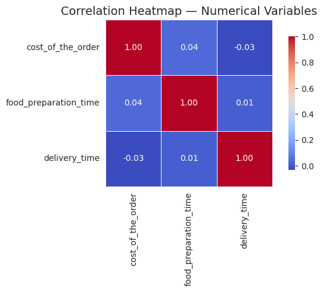

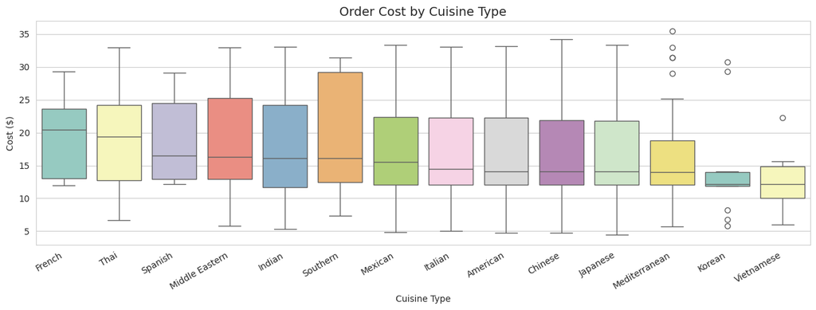

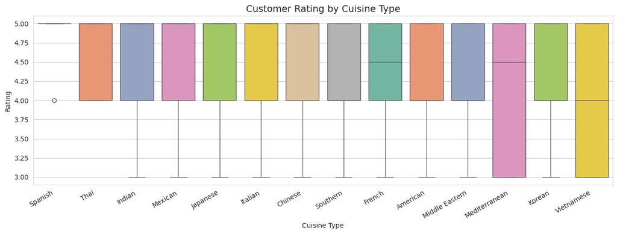

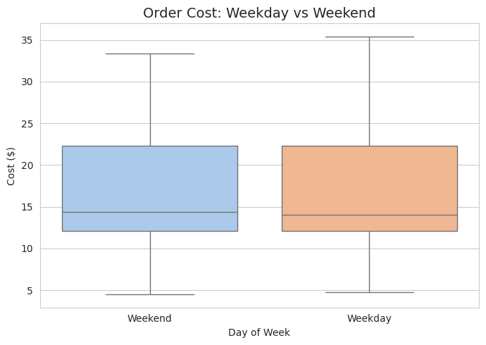

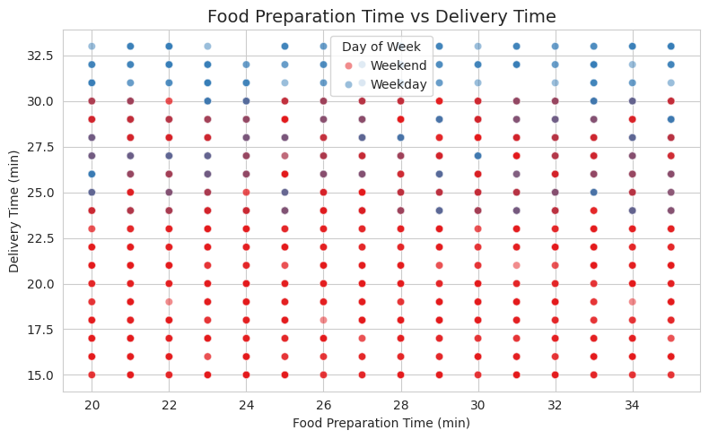

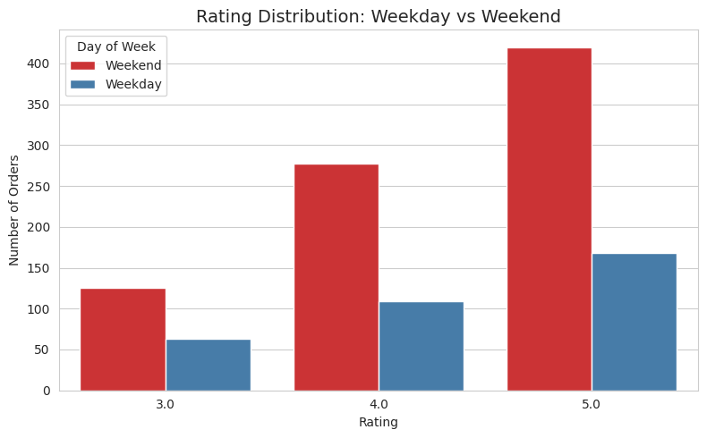

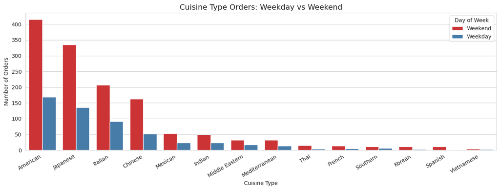

```
Multivariate analysis plots complete.
```

```python
# ─────────────────────────────────────────────────────────────────────
# Q12: Multivariate Analysis — relationships between important variables
# ─────────────────────────────────────────────────────────────────────

# --- 12a. Correlation heatmap: numerical variables ---
# We check how cost, prep time, and delivery time relate to each other
plt.figure(figsize=(7, 5))
numeric_cols = df[['cost_of_the_order', 'food_preparation_time', 'delivery_time']]
corr = numeric_cols.corr()
sns.heatmap(corr, annot=True, fmt='.2f', cmap='coolwarm',
            linewidths=0.5, square=True, cbar_kws={'shrink': 0.8})
plt.title('Correlation Heatmap — Numerical Variables', fontsize=14)
plt.tight_layout()
plt.show()

# --- 12b. Cost of order vs Cuisine type (boxplot) ---
# Which cuisines tend to have higher order costs?
cuisine_order_cost = df.groupby('cuisine_type')['cost_of_the_order'].median().sort_values(ascending=False).index
plt.figure(figsize=(13, 5))
sns.boxplot(data=df, x='cuisine_type', y='cost_of_the_order',
            order=cuisine_order_cost, palette='Set3')
plt.title('Order Cost by Cuisine Type', fontsize=14)
plt.xlabel('Cuisine Type')
plt.ylabel('Cost ($)')
plt.xticks(rotation=30, ha='right')
plt.tight_layout()
plt.show()

# --- 12c. Rating vs Cuisine type (boxplot on rated orders only) ---
rated_df = df.dropna(subset=['rating']).copy()
rated_df['rating'] = rated_df['rating'].astype(float)
plt.figure(figsize=(13, 5))
avg_rating_cuisine = rated_df.groupby('cuisine_type')['rating'].mean().sort_values(ascending=False).index
sns.boxplot(data=rated_df, x='cuisine_type', y='rating',
            order=avg_rating_cuisine, palette='Set2')
plt.title('Customer Rating by Cuisine Type', fontsize=14)
plt.xlabel('Cuisine Type')
plt.ylabel('Rating')
plt.xticks(rotation=30, ha='right')
plt.tight_layout()
plt.show()

# --- 12d. Cost vs Day of week (boxplot) ---
plt.figure(figsize=(7, 5))
sns.boxplot(data=df, x='day_of_the_week', y='cost_of_the_order', palette='pastel')
plt.title('Order Cost: Weekday vs Weekend', fontsize=14)
plt.xlabel('Day of Week')
plt.ylabel('Cost ($)')
plt.tight_layout()
plt.show()

# --- 12e. Food prep time vs Delivery time (scatter) ---
plt.figure(figsize=(8, 5))
sns.scatterplot(data=df, x='food_preparation_time', y='delivery_time',
                hue='day_of_the_week', alpha=0.5, palette='Set1')
plt.title('Food Preparation Time vs Delivery Time', fontsize=14)
plt.xlabel('Food Preparation Time (min)')
plt.ylabel('Delivery Time (min)')
plt.legend(title='Day of Week')
plt.tight_layout()
plt.show()

# --- 12f. Rating vs Day of week (countplot) ---
plt.figure(figsize=(8, 5))
sns.countplot(data=rated_df, x='rating', hue='day_of_the_week', palette='Set1')
plt.title('Rating Distribution: Weekday vs Weekend', fontsize=14)
plt.xlabel('Rating')
plt.ylabel('Number of Orders')
plt.legend(title='Day of Week')
plt.tight_layout()
plt.show()

# --- 12g. Cuisine type vs Day of week (grouped countplot) ---
plt.figure(figsize=(13, 5))
sns.countplot(data=df, x='cuisine_type',
              hue='day_of_the_week',
              order=df['cuisine_type'].value_counts().index,
              palette='Set1')
plt.title('Cuisine Type Orders: Weekday vs Weekend', fontsize=14)
plt.xlabel('Cuisine Type')
plt.ylabel('Number of Orders')
plt.xticks(rotation=30, ha='right')
plt.legend(title='Day of Week')
plt.tight_layout()
plt.show()

print('Multivariate analysis plots complete.')
```

### **Question 13:** The company wants to provide a promotional offer in the advertisement of the restaurants. The condition to get the offer is that the restaurants must have a rating count of more than 50 and the average rating should be greater than 4. Find the restaurants fulfilling the criteria to get the promotional offer. [3 marks]

```
Restaurants eligible for the promotional offer: 4

          restaurant_name  rating_count  avg_rating
        The Meatball Shop            84        4.51
Blue Ribbon Fried Chicken            64        4.33
              Shake Shack           133        4.28
        Blue Ribbon Sushi            73        4.22
```

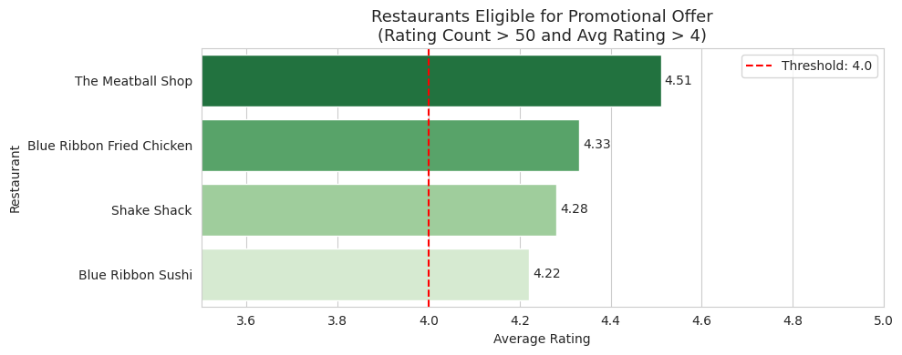

```python
# Work only with rated orders (where rating is not NaN)
rated_df = df.dropna(subset=['rating']).copy()
rated_df['rating'] = rated_df['rating'].astype(float)

# Group by restaurant: count ratings and compute average rating
rest_stats = rated_df.groupby('restaurant_name').agg(
    rating_count=('rating', 'count'),
    avg_rating=('rating', 'mean')
).reset_index()

# Apply both conditions: rating count > 50 AND average rating > 4
promo_eligible = rest_stats[
    (rest_stats['rating_count'] > 50) &
    (rest_stats['avg_rating'] > 4)
].sort_values('avg_rating', ascending=False).reset_index(drop=True)

promo_eligible['avg_rating'] = promo_eligible['avg_rating'].round(2)

print(f'Restaurants eligible for the promotional offer: {len(promo_eligible)}')
print()
print(promo_eligible.to_string(index=False))

# Visualize
plt.figure(figsize=(10, 4))
bars = sns.barplot(data=promo_eligible, y='restaurant_name', x='avg_rating',
                   palette='Greens_r')
plt.axvline(4, color='red', linestyle='--', linewidth=1.5, label='Threshold: 4.0')
plt.title('Restaurants Eligible for Promotional Offer\n(Rating Count > 50 and Avg Rating > 4)', fontsize=13)
plt.xlabel('Average Rating')
plt.ylabel('Restaurant')
plt.xlim(3.5, 5.0)
plt.legend()
for p in bars.patches:
    bars.annotate(f'{p.get_width():.2f}',
                  xy=(p.get_width(), p.get_y() + p.get_height()/2),
                  xytext=(3, 0), textcoords='offset points', va='center', fontsize=10)
plt.tight_layout()
plt.show()
```

#### Observations:

- **4 restaurants qualify** for the promotional offer (rating count > 50 AND avg rating > 4):
  1. **The Meatball Shop** — Avg rating: 4.51 | 84 rated orders *(highest rated)*
  2. **Blue Ribbon Fried Chicken** — Avg rating: 4.33 | 64 rated orders
  3. **Shake Shack** — Avg rating: 4.28 | 133 rated orders *(most rated orders)*
  4. **Blue Ribbon Sushi** — Avg rating: 4.22 | 73 rated orders
- These 4 restaurants are also the top 4 in terms of total order volume, showing a strong link between popularity and customer satisfaction.
- FoodHub should prominently feature these restaurants in marketing campaigns to leverage their consistently high customer ratings.

### **Question 14:** The company charges the restaurant 25% on the orders having cost greater than 20 dollars and 15% on the orders having cost greater than 5 dollars. Find the net revenue generated by the company across all orders. [3 marks]

```
Revenue breakdown by commission tier:
  Orders > $20   : 555 orders | Revenue = $3688.73
  Orders $5-$20  : 1334 orders | Revenue = $2477.58
  Orders <= $5   : 9 orders | Revenue = $0

NET REVENUE GENERATED: $6166.3
```

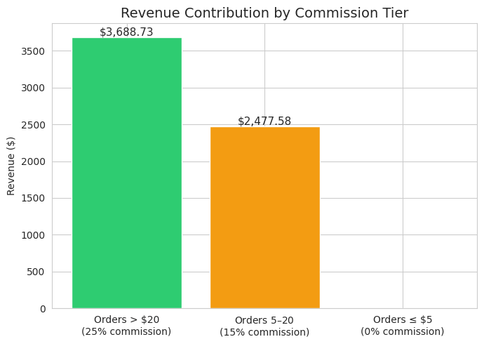

```python
# FoodHub's commission structure:
# - 25% commission on orders with cost > $20
# - 15% commission on orders with cost > $5 (and <= $20)
# - 0% commission on orders with cost <= $5

# Create a function to calculate commission per order
def calculate_commission(cost):
    if cost > 20:
        return cost * 0.25   # 25% on orders above $20
    elif cost > 5:
        return cost * 0.15   # 15% on orders between $5 and $20
    else:
        return 0             # no commission on orders <= $5

# Apply the function to every order
df['commission'] = df['cost_of_the_order'].apply(calculate_commission)

# Sum all commissions to get net revenue
net_revenue = round(df['commission'].sum(), 2)

# Breakdown by tier
orders_above_20 = (df['cost_of_the_order'] > 20).sum()
orders_5_to_20  = ((df['cost_of_the_order'] > 5) & (df['cost_of_the_order'] <= 20)).sum()
orders_under_5  = (df['cost_of_the_order'] <= 5).sum()

rev_above_20 = round(df.loc[df['cost_of_the_order'] > 20, 'commission'].sum(), 2)
rev_5_to_20  = round(df.loc[(df['cost_of_the_order'] > 5) & (df['cost_of_the_order'] <= 20), 'commission'].sum(), 2)

print('Revenue breakdown by commission tier:')
print(f'  Orders > $20   : {orders_above_20} orders | Revenue = ${rev_above_20}')
print(f'  Orders $5-$20  : {orders_5_to_20} orders | Revenue = ${rev_5_to_20}')
print(f'  Orders <= $5   : {orders_under_5} orders | Revenue = $0')
print()
print(f'NET REVENUE GENERATED: ${net_revenue}')

# Visualize revenue contribution by tier
plt.figure(figsize=(7, 5))
tiers = ['Orders > $20\n(25% commission)', 'Orders $5–$20\n(15% commission)', 'Orders ≤ $5\n(0% commission)']
revenues = [rev_above_20, rev_5_to_20, 0]
colors = ['#2ecc71', '#f39c12', '#e74c3c']
bars = plt.bar(tiers, revenues, color=colors, edgecolor='white')
plt.title('Revenue Contribution by Commission Tier', fontsize=14)
plt.ylabel('Revenue ($)')
for bar, rev in zip(bars, revenues):
    if rev > 0:
        plt.text(bar.get_x() + bar.get_width()/2, bar.get_height() + 20,
                 f'${rev:,.2f}', ha='center', fontsize=11)
plt.tight_layout()
plt.show()
```

#### Observations:

- **FoodHub's net revenue across all 1,898 orders is \$6,166.30.**
- Revenue breakdown:
  - **Orders > \$20 (25% tier):** 555 orders → **\$3,688.73** revenue (~60% of total revenue from 29% of orders)
  - **Orders \$5–\$20 (15% tier):** 1,334 orders → **\$2,477.58** revenue (~40% of total revenue from 70% of orders)
  - **Orders ≤ \$5 (0% tier):** 9 orders → \$0 revenue
- High-value orders (>\$20) generate significantly more revenue per order (avg ~\$6.64/order) compared to mid-tier orders (avg ~\$1.86/order), despite being fewer in number.
- Strategies to shift more orders above the \$20 threshold — such as bundle deals, family meal options, or free delivery above \$20 — could significantly increase FoodHub's total revenue.

### **Question 15:** The company wants to analyze the total time required to deliver the food. What percentage of orders take more than 60 minutes to get delivered from the time the order is placed? (The food has to be prepared and then delivered.) [2 marks]

```
Orders taking more than 60 minutes : 200
Total orders                        : 1898
Percentage over 60 minutes          : 10.54%
```

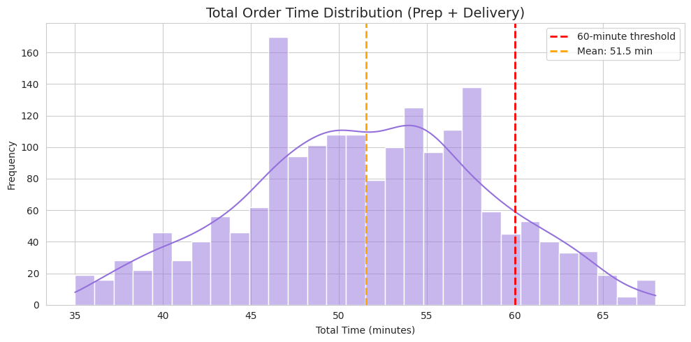

```python
# Total order time = food preparation time + delivery time
df['total_time'] = df['food_preparation_time'] + df['delivery_time']

# Count orders where total time exceeds 60 minutes
orders_over_60 = (df['total_time'] > 60).sum()
total_orders = len(df)
pct_over_60 = round((orders_over_60 / total_orders) * 100, 2)

print(f'Orders taking more than 60 minutes : {orders_over_60}')
print(f'Total orders                        : {total_orders}')
print(f'Percentage over 60 minutes          : {pct_over_60}%')

# Visualize the total time distribution with a 60-min threshold line
plt.figure(figsize=(10, 5))
sns.histplot(df['total_time'], bins=30, kde=True, color='mediumpurple')
plt.axvline(60, color='red', linestyle='--', linewidth=2, label='60-minute threshold')
plt.axvline(df['total_time'].mean(), color='orange', linestyle='--', linewidth=2,
            label=f"Mean: {df['total_time'].mean():.1f} min")
plt.title('Total Order Time Distribution (Prep + Delivery)', fontsize=14)
plt.xlabel('Total Time (minutes)')
plt.ylabel('Frequency')
plt.legend()
plt.tight_layout()
plt.show()
```

#### Observations:

- **10.54% of orders (200 out of 1,898) take more than 60 minutes** from order placement to delivery.
- The average total time is ~51.5 minutes (27.4 min prep + 24.2 min delivery).
- While 10.54% may seem small, 1 in 10 customers waiting over an hour for food is a meaningful customer experience issue.
- The 60-minute mark sits in the right tail of the distribution, meaning these long-wait orders are outliers driven by combinations of slower prep and longer delivery.
- FoodHub could introduce alerts or priority dispatch when predicted total time approaches 55 minutes.

### **Question 16:** The company wants to analyze the delivery time of the orders on weekdays and weekends. How does the mean delivery time vary during weekdays and weekends? [2 marks]

```
Mean delivery time by day of week:
day_of_the_week
Weekday    28.34
Weekend    22.47
```

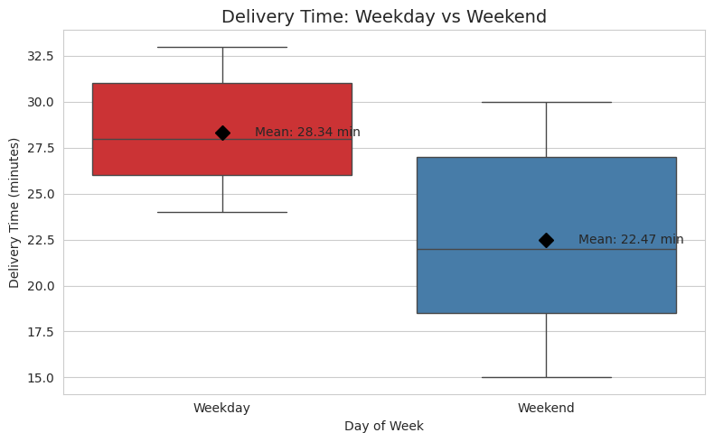

```python
# Group by day of week and compute mean delivery time
delivery_by_day = df.groupby('day_of_the_week')['delivery_time'].mean().round(2)

print('Mean delivery time by day of week:')
print(delivery_by_day.to_string())

# Visualize: boxplot for full distribution, plus mean markers
plt.figure(figsize=(8, 5))
sns.boxplot(data=df, x='day_of_the_week', y='delivery_time',
            order=['Weekday', 'Weekend'], palette='Set1')

# Overlay mean points
for i, day in enumerate(['Weekday', 'Weekend']):
    mean_val = delivery_by_day[day]
    plt.plot(i, mean_val, 'D', color='black', markersize=8, zorder=5)
    plt.text(i + 0.1, mean_val, f'Mean: {mean_val} min', va='center', fontsize=10)

plt.title('Delivery Time: Weekday vs Weekend', fontsize=14)
plt.xlabel('Day of Week')
plt.ylabel('Delivery Time (minutes)')
plt.tight_layout()
plt.show()
```

#### Observations:

- **Weekday mean delivery time: 28.34 minutes** vs **Weekend mean: 22.47 minutes**.
- Delivery is notably **faster on weekends** by about 5.9 minutes on average — a significant difference.
- This is somewhat counterintuitive; one might expect weekends to be slower due to higher order volume (1,351 weekend vs 547 weekday orders).
- A possible explanation: weekend delivery personnel may be better allocated or routes may be less congested on weekends in the residential areas served.
- FoodHub should investigate why weekday deliveries are slower and consider optimizing weekday driver allocation or routes.

### Conclusion and Recommendations

### **Question 17:** What are your conclusions from the analysis? What recommendations would you like to share to help improve the business? (You can use cuisine type and feedback ratings to drive your business recommendations.) [6 marks]

The analysis reveals key patterns in FoodHub's order data across cuisine preferences, customer ratings, delivery performance, and revenue generation. Detailed conclusions and actionable recommendations are provided below based on findings from the full exploratory data analysis.

### Conclusions:

- **Order Volume & Timing:** The dataset contains 1,898 orders placed across weekdays and weekends. Weekends account for 71% of all orders (1,351), making them the dominant business period for FoodHub.
- **Cuisine Demand:** American cuisine is the most ordered (584 orders, about 31%), followed by Japanese (470) and Italian (298). This pattern holds on weekends too — American remains the most popular weekend cuisine with 415 orders.
- **Restaurant Popularity:** Shake Shack dominates with 219 orders (about 11.5% of all orders). The top 5 restaurants — Shake Shack, The Meatball Shop, Blue Ribbon Sushi, Blue Ribbon Fried Chicken, and Parm — collectively account for 634 orders (about 33% of total).
- **Customer Ratings:** 38.78% of orders (736) were left unrated. Among rated orders, the majority received ratings of 4 or 5, indicating generally high customer satisfaction. The four restaurants eligible for the promotional offer (avg rating > 4, count > 50) are also the top-performing restaurants by volume — confirming that quality drives demand.
- **Order Cost:** The average order cost is \$16.50, ranging from \$4.47 to \$35.41. 29.24% of orders exceed \$20, which is key since FoodHub charges 25% commission on these higher-value orders vs. 15% on mid-tier orders.
- **Revenue:** FoodHub's total net revenue is **\$6,166.30** across all orders. Orders above \$20 (only 29% of volume) contribute 60% of total revenue (\$3,688.73), highlighting the outsized revenue impact of high-value orders.
- **Delivery Time:** The mean delivery time is 24.16 minutes. Notably, weekday deliveries (mean 28.34 min) are about 6 minutes slower than weekend deliveries (mean 22.47 min). 10.54% of orders (200) take more than 60 minutes in total (prep + delivery), which represents a customer experience risk.
- **Preparation Time:** Food preparation time is consistent across the dataset, ranging from 20 to 35 minutes (mean: 27.37 min), with no extreme outliers. There is minimal correlation between prep time, delivery time, and order cost.

### Recommendations:

- **Promote Top-Rated Restaurants:** The four restaurants eligible for the promotional offer (Shake Shack, The Meatball Shop, Blue Ribbon Fried Chicken, Blue Ribbon Sushi) should be prominently featured in the app and advertising. Their consistently high ratings (all above 4.2) make them strong brand ambassadors for FoodHub.
- **Improve Weekend Staffing for American & Japanese Cuisine:** Since weekends drive 71% of orders and American + Japanese cuisines dominate demand, FoodHub should ensure these restaurant partners have adequate capacity on Saturday and Sunday to prevent delays.
- **Address the 38.78% Unrated Orders:** Such a high non-rating rate suggests the app's rating prompt may not be visible or compelling enough. Introducing push notifications, small loyalty point incentives for rating, or a simpler one-tap rating at delivery confirmation could significantly increase feedback volume — giving FoodHub richer data for quality management.
- **Tackle Weekday Delivery Delays:** Weekday deliveries average 28.34 minutes vs. 22.47 minutes on weekends — a 26% difference. FoodHub should investigate whether this is driven by traffic, driver availability, or restaurant preparation speed on weekdays, and optimize driver routing or incentivize weekday delivery personnel.
- **Reduce Orders Exceeding 60 Minutes:** 10.54% of customers wait over an hour for their food. Implementing a real-time total time estimator in the app and triggering priority dispatch or compensation offers when orders approach the 55-minute mark would improve customer experience and reduce churn.
- **Increase High-Value Order Conversions:** Since orders above \$20 generate 60% of revenue despite being only 29% of volume, FoodHub should introduce strategies to nudge customers toward higher spend — such as 'add-on' suggestions at checkout, combo meal promotions for popular restaurants, or free delivery for orders above \$20.
- **Expand Underserved Cuisine Categories:** Vietnamese (7 orders), Korean (13), and Spanish (12) cuisines have very few orders. If there is latent demand, partnering with more restaurants in these categories could broaden FoodHub's appeal and attract new customer segments.
- **Loyalty Program Expansion:** The current top 3 customers placed 13, 10, and 9 orders respectively. Extending the 20% discount program to a broader loyalty tier (e.g., top 50 customers) and adding tiered rewards could increase repeat order frequency across a larger portion of the customer base.